# Python Training

**GIT**

cd "C:\Users\User\Documents\Computer science, Data Science Resources\Data Science\Python\Python for Finance Course\Practice"

git commit -a -m "Comment"

git push origin master

Recall, we can specify a cell as a Markdown cell by pressing M. Python is very similar to R in general, however it does not make the same use of vectorization as R and has a more general structure, as it can be used for a variety of programming problems

## Functions

```python
#Create a function using def and include an argument
def plus_ten(x):
    #Using the return statement is good programming practice- REMEMBER INDENTATION
    value = str(x + 10)
    statement = 'The value is:' + value
    return (statement)
```

```python
plus_ten(2)
```

```
'The value is:12'
```

```python
#Here we create a function with the following pseudo code
#1) input x
#2) whilst x < 1000:
    #a) x = x + 3
    #b) store x in a dataframe
#3) return the dataframe

def dataframe_output(x):
    #Check if the argument type is valid (i.e. an integer)
    if type(x) != int:
        return("Invalid Argument")
    data = list()
    while x < 1000:
        #We need to use the append method, because we can't concatenate object of different types into a list
        #append allows us to concatenate different values into the list
        data.append(x)
        x += 3
    return(data)
```

```python
dataframe_output(2)
```

```
[2,
 5,
 8,
 11,
 14,
 17,
 20,
 23,
 26,
 29,
 32,
 35,
 38,
 41,
 44,
 47,
 50,
 53,
 56,
 59,
 62,
 65,
 68,
 71,
 74,
 77,
 80,
 83,
 86,
 89,
 92,
 95,
 98,
 101,
 104,
 107,
 110,
 113,
 116,
 119,
```

[output cut: 278 more lines]

```
 956,
 959,
 962,
 965,
 968,
 971,
 974,
 977,
 980,
 983,
 986,
 989,
 992,
 995,
 998]
```

## Variable Types

```python
x = 1
type(x)
```

```
int
```

```python
type(x) == int
```

```
True
```

```python
dataframe_output(True)
```

```
'Invalid Argument'
```

We can also convert variables into the specific type we want

```python
x2 = 8.00
int(x2)
```

```
8
```

```python
float(x2)
```

```
8.0
```

Python displays strings with text quotes included, unless we use the print() statement

```python
'Hello'
print('Hello')
```

```
Hello
```

We can also concatenate strings and other values

```python
print(str(x2) + 'Dollars')
```

```
8.0Dollars
```

```python
print(str(x2), 'Dollars', str(True))
```

```
8.0 Dollars True
```

Recall in Python we index from ZERO and not from one. We can use this to extract elements of a list as well as extract elements of a text string, etc.

```python
"Friday"[0]
```

```
'F'
```

We can use logical and identity operators, such as AND, NOT, OR. These have a HIERARCHY OF IMPORTANCE (similar to BIDMAS):

1) NOT

2) AND

3) OR

```python
True and not False or not True and False
```

```
True
```

## Functions and Conditional Iteration

Conditional Iteration in Python is very similar to that of R- we can use If/else statements, while, etc.

```python
x = 1

if x > 3:
    print("BIG")
if x < -3:
    print("small")
else:
    print("nobody cares")
```

```
nobody cares
```

NOTE- if the return() statement is reached in a function, the function is stopped and the output of the return statement is provided

As with R, and any other programming language for that matter, we can write functions within other functions

```python
def Wage(hours):
    return(10.5 * hours)

def WageWithBonus(hours):
    return(Wage(hours) + 10)

WageWithBonus(12)
```

```
136.0
```

We can also create functions containing several arguments

```python
def subtract(a = 1, b, c):
    return(a + b *c)
```

```
  File "<ipython-input-17-3d85a327b8f7>", line 1
    def subtract(a = 1, b, c):
                ^
SyntaxError: non-default argument follows default argument
```

Note in tha above code that assigning a default argument first DOES NOT WORK. This is because we need non-defaulted arguments first, so that Python will know what to use for the arguments wihout defaults if the function is called with less arguments than it has

```python
def subtract(b, c, a = 1):
    return(a + b * c)
```

```python
subtract(1, 2)
```

```
3
```

```python
subtract(1, 2, 1)
```

```
3
```

## Python Sequences

### Lists

A list contains a sequence of data points, such as floats, Booleans, integers, strings, etc. We use SQUARE BRACKETS to create lists. We can also slice lists, and they are similar to vectors in R. Pandas and Numpy also have their own types of list, as well as other data objects. Lists are also similar to arrays in R, in that we can creates lists of lists, etc.

```python
Family = ['Ida', 'Giulia', 'Dom']
```

```python
Family[1]
```

```
'Giulia'
```

```python
Family[-1]
```

```
'Dom'
```

We can add and remove items into the list

```python
del Family[2]
```

The append method is an example of object-oriented programming. It is a function that can be applied to lists, as the object. Methods in Python are applied as object.method()

```python
Family.append("Dom")
```

```python
Family
```

```
['Ida', 'Giulia', 'Dom']
```

We can arrive at the same result using the method 'extend'. This also enables us to include more than one item in the list to append

```python
Family.extend(['Andrew', 'Vicky', 'Vaughn'])
```

Slicing lists is easy and we can also use the index method to find the index of the corresponding element of the list

```python
Family[1:3]
```

```
['Giulia', 'Dom']
```

```python
Family.index("Dom")
```

```
2
```

We can create a list of lists

```python
Family2 = ['Nick', 'Judith', 'Harry', 'Charlie the Dog']
BigFamily = [Family, Family2]
```

```python
BigFamily
```

```
[['Ida', 'Giulia', 'Dom', 'Andrew', 'Vicky', 'Vaughn'],
 ['Nick', 'Judith', 'Harry', 'Charlie the Dog']]
```

There are many methods we can apply, including the sort method

```python
Family.sort()
Family
```

```
['Andrew', 'Dom', 'Giulia', 'Ida', 'Vaughn', 'Vicky']
```

### Tuples

```python
z = (10, 20 , 30)
```

```python
z
z[1]
```

```
20
```

```python
z[1] = 10
```

```
---------------------------------------------------------------------------
TypeError                                 Traceback (most recent call last)
<ipython-input-15-72bcf5b7359d> in <module>
----> 1 z[1] = 10

TypeError: 'tuple' object does not support item assignment
```

```python
(age, years_of_school) = "30, 17".split(',')
```

```python
age
```

```
'30'
```

We can also use tuples when outputting the results of functions- this is again useful as it ensures the output cannot be altered.

```python
def square_info(x):
    A = x ** 2
    P = 4 * x
    print("Area and paramter:")
    return (A, P)
```

```python
square_info(2)
```

```
Area and paramter:
```

```
(4, 8)
```

### Dictionaries

Dictionaries are another way of storing data- each value in a dictionary is associated with a key- a key and its respective value form a key-value pair. After a dictionary is created, each value can be accessed by its key. This could be useful, for example when we have a company as the key and its stock price as the value- enables to look up and return values associated with a given key

```python
dict = {'Apple': 102.9, 'Amazon': 110.9, 'Facebook Wankers': -9.02}
```

```python
dict['Apple']
```

```
102.9
```

```python
HouseholdTeams = {'dep_1':["hello", "goodbye"], 'dep_2':20}
```

```python
HouseholdTeams['dep_1']
```

```
['hello', 'goodbye']
```

We can also create dictionaries as follows:

```python
Team = {}
Team['Anchor'] = 'Dom'
Team['Wastemen'] = ['Bradford', 'MK Dons']
Team
```

```
{'Anchor': 'Dom', 'Wastemen': ['Bradford', 'MK Dons']}
```

## Iteration

We can iterate over both a range of values and a list of items

```python
x = list(range(10))
for i in range(10):
    x[i] = 2 * i
```

```python
x
```

```
[0, 2, 4, 6, 8, 10, 12, 14, 16, 18]
```

```python
for n in x:
    print(n)
```

```
0
2
4
6
8
10
12
14
16
18
```

We can also use the HELP function.

```python
help(range)
```

[output not shown]

```python
list(range(0, 10, 2))
#The arguments are for start, stop and finally step, the increment for each value
```

```
[0, 2, 4, 6, 8]
```

```python
list(range(0, 10))
```

```
[0, 1, 2, 3, 4, 5, 6, 7, 8, 9]
```

```python
x = [0, 1, 2]

for i in x:
    print(i)
```

```
0
1
2
```

```python
for i in range(len(x)):
    print(i)
```

```
0
1
2
```

We can also iterate over DICTIONARIES

```python
prices = {
    "cheese":4,
    "chicken":5.20,
    "Leek": 0.75
}

quantity = {
    "cheese":4,
    "chicken":5,
    "Leek": 7
}
```

```python
money_spent = 0

for i in prices:
    #reloop over which retains money_spent
    money_spent = money_spent + (prices[i] * quantity[i])
```

```python
for i in prices:
    if prices[i] < 5:
        money_spent = money_spent + (prices[i] * quantity[i])
    else:
        money_spent = money_spent
```

## External Packages

Recall, there are several ways to import packages into Python

```python
from math import sqrt
```

In general we need to use the DOT operator before the package name, unless we import specific functions

```python
sqrt(3)
```

```
1.7320508075688772
```

```python
import numpy as np
import pandas as pd
import matplotlib as plt
import quandl as qd
```

For packages that ar not installed in anaconda, we need to use pip install in Anaconda Prompt. Numpy arrays are similar to vectors or matrices in R, although typically aren't as easy to access or use. Therefore Pandas Dataframes are the better option for Data Science and Statistical problems

### Numpy

```python
a = np.array([[0, 1, 2, 3], [2, 3, 4, 5]])
a.shape
```

```
(2, 4)
```

We can also redefine the values of the elements in the array

```python
a
```

```
array([[0, 1, 2, 3],
       [2, 3, 4, 5]])
```

```python
a[1, 2] = 100
a
```

```
array([[  0,   1,   2,   3],
       [  2,   3, 100,   5]])
```

We can also generate random numbers

```python
import random
probs = random.random()
print(probs)
```

```
0.998614247698865
```

We can also create an array/ matrix of randomly generated values

```python
#Matrix of random integers in 4 x 6 matrix
np.random.randint(1, 6, (4, 6))
```

```
array([[4, 3, 5, 2, 2, 3],
       [4, 4, 5, 5, 3, 3],
       [3, 1, 3, 5, 4, 1],
       [2, 1, 2, 5, 4, 5]])
```

### Pandas

We can create dataframes, as well as time series data objects using Pandas. That is there are 2 data types in Pandas:

1) Series

2) Dataframes

```python
ser = pd.Series(np.random.random(5), name = "Volume")
```

```python
ser
```

```
0    0.922529
1    0.908368
2    0.152931
3    0.511490
4    0.425428
Name: Volume, dtype: float64
```

The Data package enables us to import data from APIs as Pandas Dataframes

```python
from pandas_datareader import data as wb
```

```python
PG = wb.DataReader("PG", data_source="yahoo", start = "1995-1-1")
#Daily price data
PG
```

| Date | High | Low | Open | Close | Volume | Adj Close |
| --- | --- | --- | --- | --- | --- | --- |
| 1995-01-03 | 15.625000 | 15.437500 | 15.468750 | 15.593750 | 3318400.0 | 8.215732 |
| 1995-01-04 | 15.656250 | 15.312500 | 15.531250 | 15.468750 | 2218800.0 | 8.149876 |
| 1995-01-05 | 15.437500 | 15.218750 | 15.375000 | 15.250000 | 2319600.0 | 8.034625 |
| 1995-01-06 | 15.406250 | 15.156250 | 15.156250 | 15.281250 | 3438000.0 | 8.051086 |
| 1995-01-09 | 15.406250 | 15.187500 | 15.343750 | 15.218750 | 1795200.0 | 8.018162 |
| 1995-01-10 | 15.437500 | 15.187500 | 15.281250 | 15.406250 | 4364000.0 | 8.116948 |
| 1995-01-11 | 15.593750 | 15.375000 | 15.593750 | 15.375000 | 3738400.0 | 8.100482 |
| 1995-01-12 | 15.531250 | 15.312500 | 15.375000 | 15.531250 | 3307600.0 | 8.182804 |
| 1995-01-13 | 15.843750 | 15.531250 | 15.593750 | 15.625000 | 3992800.0 | 8.278837 |
| 1995-01-16 | 15.968750 | 15.750000 | 15.906250 | 15.750000 | 3677200.0 | 8.345070 |
| 1995-01-17 | 15.812500 | 15.656250 | 15.718750 | 15.812500 | 2437600.0 | 8.378183 |
| 1995-01-18 | 15.750000 | 15.437500 | 15.687500 | 15.468750 | 3535200.0 | 8.196052 |
| 1995-01-19 | 15.406250 | 15.343750 | 15.343750 | 15.406250 | 2491200.0 | 8.162930 |
| 1995-01-20 | 15.406250 | 15.250000 | 15.406250 | 15.343750 | 5130800.0 | 8.129820 |
| 1995-01-23 | 15.500000 | 15.187500 | 15.187500 | 15.500000 | 3147200.0 | 8.212608 |
| 1995-01-24 | 15.531250 | 15.375000 | 15.500000 | 15.468750 | 2016400.0 | 8.196052 |
| 1995-01-25 | 15.781250 | 15.437500 | 15.500000 | 15.687500 | 2802400.0 | 8.311955 |
| 1995-01-26 | 15.843750 | 15.687500 | 15.718750 | 15.750000 | 3124000.0 | 8.345070 |
| 1995-01-27 | 16.250000 | 15.812500 | 15.812500 | 16.187500 | 6247200.0 | 8.576874 |
| 1995-01-30 | 16.562500 | 16.093750 | 16.125000 | 16.437500 | 5226400.0 | 8.709341 |
| 1995-01-31 | 16.500000 | 16.281250 | 16.343750 | 16.281250 | 3934800.0 | 8.626549 |
| 1995-02-01 | 16.343750 | 15.937500 | 16.343750 | 15.968750 | 3047200.0 | 8.460968 |
| 1995-02-02 | 16.125000 | 15.875000 | 15.968750 | 16.093750 | 3810400.0 | 8.527206 |
| 1995-02-03 | 16.375000 | 16.187500 | 16.218750 | 16.250000 | 4442800.0 | 8.609992 |
| 1995-02-06 | 16.625000 | 16.281250 | 16.281250 | 16.625000 | 4003600.0 | 8.808681 |
| 1995-02-07 | 16.593750 | 16.406250 | 16.562500 | 16.593750 | 2380400.0 | 8.792128 |
| 1995-02-08 | 16.593750 | 16.406250 | 16.593750 | 16.406250 | 2481200.0 | 8.692779 |
| 1995-02-09 | 16.468750 | 16.312500 | 16.437500 | 16.375000 | 2143600.0 | 8.676225 |
| 1995-02-10 | 16.406250 | 16.156250 | 16.343750 | 16.343750 | 2445600.0 | 8.659663 |
| 1995-02-13 | 16.468750 | 16.312500 | 16.312500 | 16.468750 | 1726400.0 | 8.725892 |
| ... | ... | ... | ... | ... | ... | ... |
| 2020-10-08 | 141.929993 | 140.360001 | 140.559998 | 141.649994 | 4569800.0 | 140.867828 |
| 2020-10-09 | 143.639999 | 141.699997 | 141.839996 | 142.919998 | 6551700.0 | 142.130814 |
| 2020-10-12 | 145.330002 | 143.330002 | 143.330002 | 144.490005 | 5791500.0 | 143.692154 |
| 2020-10-13 | 144.839996 | 143.460007 | 143.820007 | 144.210007 | 4509400.0 | 143.413696 |
| 2020-10-14 | 145.100006 | 143.080002 | 144.179993 | 144.039993 | 3860700.0 | 143.244629 |
| 2020-10-15 | 144.389999 | 142.889999 | 143.059998 | 143.830002 | 4997100.0 | 143.035797 |
| 2020-10-16 | 145.869995 | 143.919998 | 144.419998 | 144.389999 | 6806100.0 | 143.592697 |
| 2020-10-19 | 145.389999 | 141.130005 | 144.470001 | 141.910004 | 6427600.0 | 141.126404 |
| 2020-10-20 | 145.690002 | 141.899994 | 145.610001 | 142.479996 | 7582100.0 | 141.693237 |
| 2020-10-21 | 144.339996 | 142.470001 | 142.490005 | 143.250000 | 5649700.0 | 142.459000 |
| 2020-10-22 | 142.750000 | 141.080002 | 141.490005 | 141.449997 | 4502900.0 | 141.449997 |
| 2020-10-23 | 142.880005 | 141.759995 | 141.759995 | 142.380005 | 4278100.0 | 142.380005 |
| 2020-10-26 | 142.050003 | 140.009995 | 141.500000 | 141.300003 | 5315500.0 | 141.300003 |
| 2020-10-27 | 143.339996 | 141.649994 | 141.940002 | 142.360001 | 6806700.0 | 142.360001 |
| 2020-10-28 | 140.940002 | 137.309998 | 140.449997 | 137.660004 | 8192200.0 | 137.660004 |
| 2020-10-29 | 139.089996 | 135.800003 | 137.350006 | 137.570007 | 5476900.0 | 137.570007 |
| 2020-10-30 | 137.990005 | 134.679993 | 137.179993 | 137.100006 | 6422000.0 | 137.100006 |
| 2020-11-02 | 140.000000 | 137.440002 | 138.509995 | 138.500000 | 6682800.0 | 138.500000 |
| 2020-11-03 | 142.660004 | 139.320007 | 139.320007 | 141.220001 | 6244200.0 | 141.220001 |
| 2020-11-04 | 143.000000 | 140.270004 | 140.460007 | 140.639999 | 5820600.0 | 140.639999 |
| 2020-11-05 | 143.529999 | 141.779999 | 142.440002 | 142.380005 | 5673100.0 | 142.380005 |
| 2020-11-06 | 144.070007 | 142.380005 | 142.669998 | 143.229996 | 4702300.0 | 143.229996 |
| 2020-11-09 | 146.919998 | 137.600006 | 146.149994 | 137.990005 | 12664700.0 | 137.990005 |
| 2020-11-10 | 140.619995 | 137.149994 | 138.100006 | 140.259995 | 7854000.0 | 140.259995 |
| 2020-11-11 | 143.000000 | 140.649994 | 141.850006 | 142.070007 | 5554300.0 | 142.070007 |
| 2020-11-12 | 142.550003 | 141.070007 | 142.289993 | 142.149994 | 5631700.0 | 142.149994 |
| 2020-11-13 | 144.479996 | 141.880005 | 142.210007 | 144.279999 | 6466800.0 | 144.279999 |
| 2020-11-16 | 144.779999 | 141.259995 | 144.779999 | 142.429993 | 7976600.0 | 142.429993 |
| 2020-11-17 | 143.470001 | 141.750000 | 141.889999 | 141.880005 | 6396000.0 | 141.880005 |
| 2020-11-18 | 142.100006 | 140.559906 | 141.990005 | 140.639999 | 3152753.0 | 140.639999 |

6518 rows × 6 columns

We can use the info() method on Pandas DataFrames to summarize the information in a Pandas DataFrame

```python
PG.info()
```

```
<class 'pandas.core.frame.DataFrame'>
DatetimeIndex: 6518 entries, 1995-01-03 to 2020-11-18
Data columns (total 6 columns):
High         6518 non-null float64
Low          6518 non-null float64
Open         6518 non-null float64
Close        6518 non-null float64
Volume       6518 non-null float64
Adj Close    6518 non-null float64
dtypes: float64(6)
memory usage: 356.5 KB
```

We can also create a dataframe from mahy different companies, by creating a list of company tickers and iterating over that list

```python
tickers = ['AAPL', 'MSFT', 'F']

new_data = pd.DataFrame()
for t in tickers:
    new_data[t] = wb.DataReader(t, data_source = "yahoo", start = "2000-1-1")['Close']
```

```python
new_data.head(3)
```

[output not shown]

We can save and load data files and we typically save them as csv. Either use the method .to_csv or the method read.csv to load and save Pandas Dataframe files. Make sure we use the FORWARD SLASH and not the backslash. NOTE- This read.csv method is specifically a PANDAS method

```python
new_data.to_csv("C:/Users/User/Documents/Computer science, Data Science Resources/Data Science/Python/Python for Finance Course/Practice/StockData.csv")
```

```python
#Read in the same data (add file path)
#new_data = pd.read_csv
```

## Financial Analysis

### Calculating Returns

```python
import numpy as np
from pandas_datareader import data as wb
import matplotlib.pyplot as plt
```

```python
PG = wb.DataReader('PG', data_source = 'yahoo', start = '1995-1-1')
```

First calculated simple returns

$Simple Return_t = \frac{P_t - P_{t - 1}}{P_{t - 1}}$

```python
PG['Simple Return'] = (PG['Adj Close'] - PG['Adj Close'].shift(1)) / PG['Adj Close'].shift(1)
```

```python
PG.head()
```

| Date | High | Low | Open | Close | Volume | Adj Close | Simple Return |
| --- | --- | --- | --- | --- | --- | --- | --- |
| 1995-01-03 | 15.62500 | 15.43750 | 15.46875 | 15.59375 | 3318400.0 | 8.215732 | NaN |
| 1995-01-04 | 15.65625 | 15.31250 | 15.53125 | 15.46875 | 2218800.0 | 8.149876 | -0.008016 |
| 1995-01-05 | 15.43750 | 15.21875 | 15.37500 | 15.25000 | 2319600.0 | 8.034625 | -0.014141 |
| 1995-01-06 | 15.40625 | 15.15625 | 15.15625 | 15.28125 | 3438000.0 | 8.051086 | 0.002049 |
| 1995-01-09 | 15.40625 | 15.18750 | 15.34375 | 15.21875 | 1795200.0 | 8.018162 | -0.004089 |

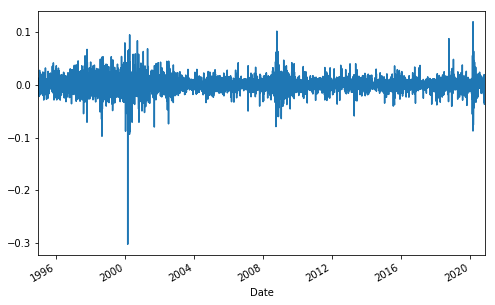

```python
PG['Simple Return'].plot(figsize = (8, 5))
```

We can also calculate Log Returns = $ln(\frac{P_t}{P_{t - 1}})$. Note how below we use the package nump in order to take logarithmic transformations

```python
PG['Log Return'] = np.log(PG['Adj Close'] / PG['Adj Close'].shift(1))
```

```python
PG['Log Return'].head()
```

```
Date
1995-01-03         NaN
1995-01-04   -0.008048
1995-01-05   -0.014242
1995-01-06    0.002047
1995-01-09   -0.004098
Name: Log Return, dtype: float64
```

### .iloc and .loc

.loc is a label-based method of selection, that is we need to pass it string values, such as column or row NAMES. Here we use it to filter observations with PG price greater than 60

```python
new_data.loc[new_data.PG > 60]
```

[output not shown]

3358 rows × 4 columns

.iloc is an index-based selection method. It is more closely aligned to the matrix-notation in R. We can set specific indices relating to the row and column numbers to subset the data.

```python
#Row 1
new_data.iloc[0]
```

[output not shown]

```python
#First 6 observations for MSFT
new_data.iloc[0:5, 1]
```

```
Date
2000-01-03    58.28125
2000-01-04    56.31250
2000-01-05    56.90625
2000-01-06    55.00000
2000-01-07    55.71875
Name: MSFT, dtype: float64
```

We can calculate covariance and correlation matrices between stock prices using the methods .cov() and .corr() for Pandas DataFrames

```python
new_data.cov()
```

[output not shown]

```python
new_data.corr()
```

[output not shown]

### Portfolio Variance & Volatility

We can can calculate the portfolio variance and volatility using the dot product method. Remeber to use the LOG returns.

$Portfolio Variance = w^T \Sigma w$

```python
log_returns = np.log(new_data / new_data.shift(1))
log_returns.head()
```

| Date | AAPL | MSFT | F |
| --- | --- | --- | --- |
| 2000-01-03 | NaN | NaN | NaN |
| 2000-01-04 | -0.088078 | -0.034364 | -0.033984 |
| 2000-01-05 | 0.014528 | 0.010489 | 0.003697 |
| 2000-01-06 | -0.090514 | -0.034072 | 0.001229 |
| 2000-01-07 | 0.046281 | 0.012984 | 0.071120 |

```python
weights = np.array([0.2, 0.3, 0.5])
```

```python
pfolio_var = np.dot(weights.T, np.dot(log_returns.cov() * 250, weights))
print("The portfolio variance is 8.96%:")
pfolio_var
```

```
The portfolio variance is 8.96%:
```

```
0.08963389637917411
```

We can also calculate Diversifiable and Systematic risk- we take the weighted annual variances for each stock away from the portfolio variance. These individual variances are the individuals risks faced by each company and are in themselves non-diversifiable

### Multivariate Regression

We can carry out regression in Python using a number of packages, including stats, statsmodels and scikit-learn

```python
import numpy as np
import pandas as pd

from scipy import stats

import matplotlib.pyplot as plt
```

```python
data = pd.read_excel('C:/Users/User/Documents/Computer science, Data Science Resources/Data Science/Python/Python for Finance Course/Practice/Housing.xlsx')
```

Extract the response and independent variables for the regression

```python
data.columns = ['Variable', 'Price', 'Size']
```

```python
#drop first 4 observations
data = data.drop([0, 1, 2, 3])
```

```python
X = data['Size']
y = data['Price']
```

[figure not shown]

```python
plt.scatter(X, y)
plt.axis([0, 2500, 0, 1500000])
plt.ylabel('House Price')
plt.xlabel('House Size')
plt.show()
```

```python
data
```

|  | Variable | Price | Size |
| --- | --- | --- | --- |
| 4 | NaN | 673 | 950000 |
| 5 | NaN | 785 | 454000 |
| 6 | NaN | 900 | 1.27043e+06 |
| 7 | NaN | 599 | 350000 |
| 8 | NaN | 975 | 900000 |

For the stats.models package, we need to add a constant to the design matrix

### Markowitz Portfolio Optimization

We can consider altering the weights of the stocks in our portfolio and choose the weights that yield the best trade-off between the expected return and portfolio volatility (MAXIMIZE THE SHARPE RATIO)

```python
import numpy as np
import pandas as pd
from pandas_datareader import data as wb

import matplotlib.pyplot as plt
```

```python
#FTSE250 and Lloyds Bank
assets = ['PG', '^GSPC']
```

```python
pf_data = pd.DataFrame()

for t in assets:
    pf_data[t] = wb.DataReader(t, data_source='yahoo', start = '2010-1-1')['Adj Close']
```

```python
help(wb.DataReader)
```

[output not shown]

Recall, expected portfolio returns is given by the sum of the weighted annualized log returns and the portfolio volatility is the square root of the portfolio variance, which is a combination of the variance of the returns of each stock and the covariance of the returns between the stocks in the portfolio

```python
log_returns = np.log(pf_data / pf_data.shift(1))
num_assets = len(assets)

#create empty lists
pfolio_returns = []
pfolio_volatility = []

for x in range(1000):
    weights = np.random.random(num_assets)
    weights = weights / np.sum(weights)
    #Portfolio returns = weighted annualized returns for each stock
    pfolio_returns.append(np.sum(weights * log_returns.mean() * 250))
    #Portfolio volatility = square root of portfolio variance
    pfolio_volatility.append(np.sqrt(np.dot(weights.T, np.dot(log_returns.cov() * 250, weights))))
```

Now we can convert these weights to an array and plot the corresponding Expected Volatility - Expected Return Trade-Off

```python
pfolio_returns = np.array(pfolio_returns)
pfolio_volatility = np.array(pfolio_volatility)
```

```python
#Create DataFrame
portfolio = pd.DataFrame({'Return': pfolio_returns, 'Volatility': pfolio_volatility})
```

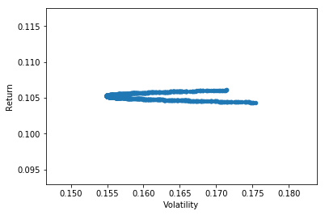

```python
portfolio.plot(x = 'Volatility', y = 'Return', kind = 'scatter')
plt.xlim = [0.15, 0.18]
plt.ylim = [0.1, 0.11]
```

### CAPM

Recall, the CAPM enables us to calculate the expected return of a portfolio of stocks. We use the $\beta$-coefficient which considers the covariance between the returns of a stock and the return of the market portfolio.

First calculate the log returns and annualized covariance matrix for the market portfolio and the stock (P&G)

```python
log_returns = np.log(pf_data / pf_data.shift(1))
```

```python
cov_returns = log_returns.cov() *250
```

```python
#Extract the covariance- off dimensional
cov_with_market = cov_returns.iloc[0, 1]
market_var = log_returns['^GSPC'].var() * 250
```

Now we can calculate the beta-coefficient- to what extent does the stock move in the same direction as the market index

```python
PG_beta = cov_with_market / market_var
PG_beta
```

```
0.5830329439820414
```

We can then calculate the expected return, by assuming the risk free return of 1.75% and a market premium of 6.25%

```python
PG_er = 0.0175 + PG_beta * (0.0625)
PG_er
```

```
0.05393955899887759
```

Finally we can calculate the performance of the stock relative to the amount of risk associated with it

```python
Sharpe_Ratio = (PG_er - 0.0175) / ((log_returns['PG'].std() * 250) ** 0.5)
```

```python
Sharpe_Ratio
```

```
0.02213244364599492
```

### Multivariate Regression

We can use the scipy package from the stats module to carry out multivariate regression. In this case we must be careful as number bedrooms and house size are correlated and hence illustrate problems of collinearity.

```python
import numpy as np
import pandas as pd
from scipy import stats
```

```python
houseData = pd.read_excel('C:/Users/User/Documents/Computer science, Data Science Resources/Data Science/Python/Python for Finance Course/Practice/Housing.xlsx')
```

```python
houseData.head()
```

|  | House Price | House Size (sq.ft.) | State | Number of Rooms | Year of Construction |
| --- | --- | --- | --- | --- | --- |
| 0 | 1116000 | 1940 | IN | 8 | 2002 |
| 1 | 860000 | 1300 | IN | 5 | 1992 |
| 2 | 818400 | 1420 | IN | 6 | 1987 |
| 3 | 1000000 | 1680 | IN | 7 | 2000 |
| 4 | 640000 | 1270 | IN | 5 | 1995 |

Now extract the explanatory features and the target response variable

```python
X = houseData[['Number of Rooms', 'Year of Construction']]
y = houseData['House Price']
```

[output not shown]

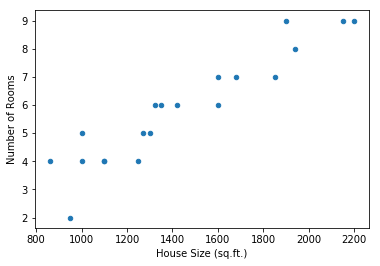

```python
houseData.plot(x = 'House Size (sq.ft.)', y = 'Number of Rooms', kind = 'scatter')
plt.show()
```

We then run and fit the relevant model and install the required package (pip install statsmodels). The statsmodels library is a rigorous python library that includes a huge array of statistical modelling techniques: GLMs, mixed effects models, PCA, GLMM, panel data, linear regression, zero inflated error models, time series, ...

```python
import statsmodels as sm
```

```python
import matplotlib.pyplot as plt
```

We must then add a constant to the design matrix and fit the linear regression using OLS and apply the fit method

```python
X1 = sm.add_constant(X)
reg = sm.OLS(y, X1).fit()

reg.summary()
```

```
---------------------------------------------------------------------------
AttributeError                            Traceback (most recent call last)
<ipython-input-19-edd04230a01d> in <module>
----> 1 X1 = sm.add_constant(X)
      2 reg = sm.OLS(y, X1).fit()
      3
      4 reg.summary()

AttributeError: module 'statsmodels' has no attribute 'add_constant'
```

```python
reg = sm.OLS(y, X).fit()

reg.summary()
```

```
---------------------------------------------------------------------------
AttributeError                            Traceback (most recent call last)
<ipython-input-20-4683e6f55a01> in <module>
----> 1 reg = sm.OLS(y, X).fit()
      2
      3 reg.summary()

AttributeError: module 'statsmodels' has no attribute 'OLS'
```